# GDP per Capita and Child Mortality in 2020

Cross-country comparison

Week 2 Workshop

May 18, 2026

## Indicators

This report compares two country-level development indicators for **2020**:

1. **GDP per capita (international-$)** — economic output per person, adjusted for international dollars.
2. **Child mortality (deaths per 1,000 live births, ages 0–5)** — number of children who die before age five per 1,000 live births.

Each indicator is subset to the year 2020. The sample sizes are 193 countries with GDP data and 194 with child mortality data; 193 countries have both values and appear in the scatterplot below.

## World map: GDP per capita (2020)

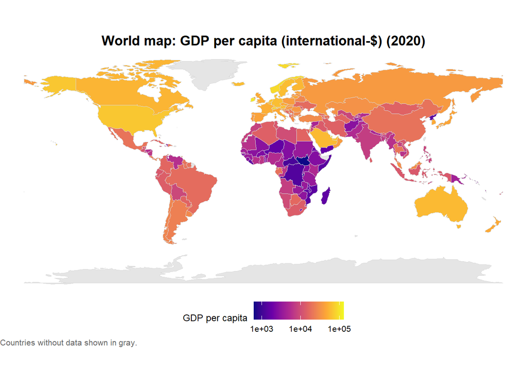

## World map: Child mortality (2020)

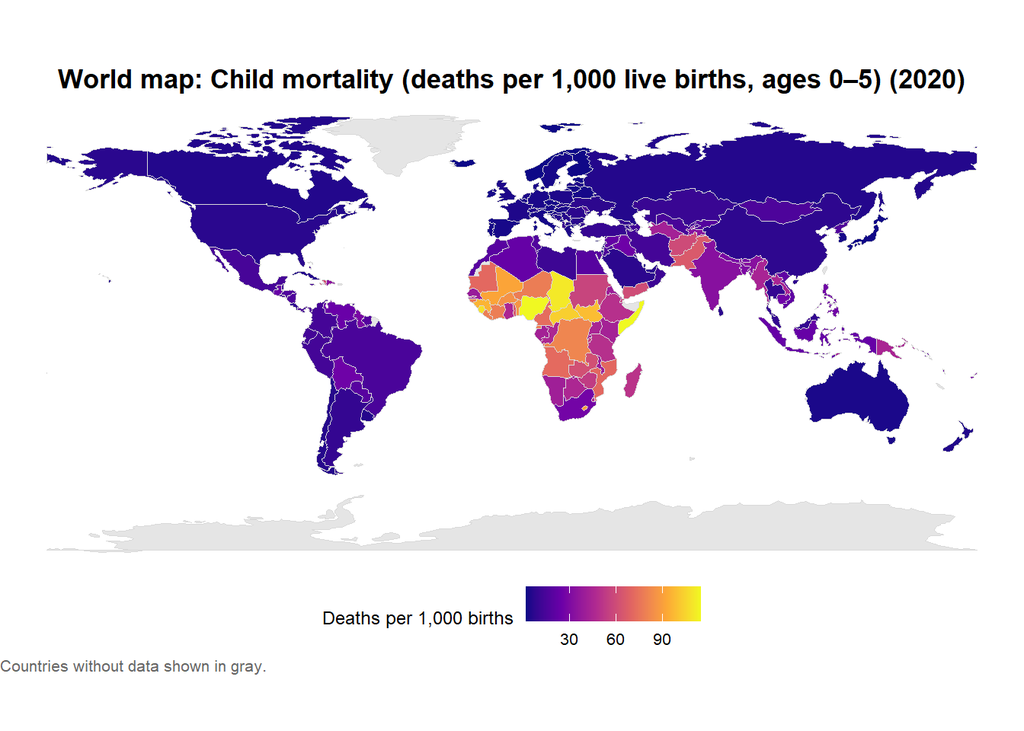

Child mortality is highest across much of sub-Saharan Africa and pockets of South Asia, and lowest in Europe, North America, East Asia, and Australia. The geographic pattern is broadly the inverse of the GDP map.

## Relationship between indicators (2020)

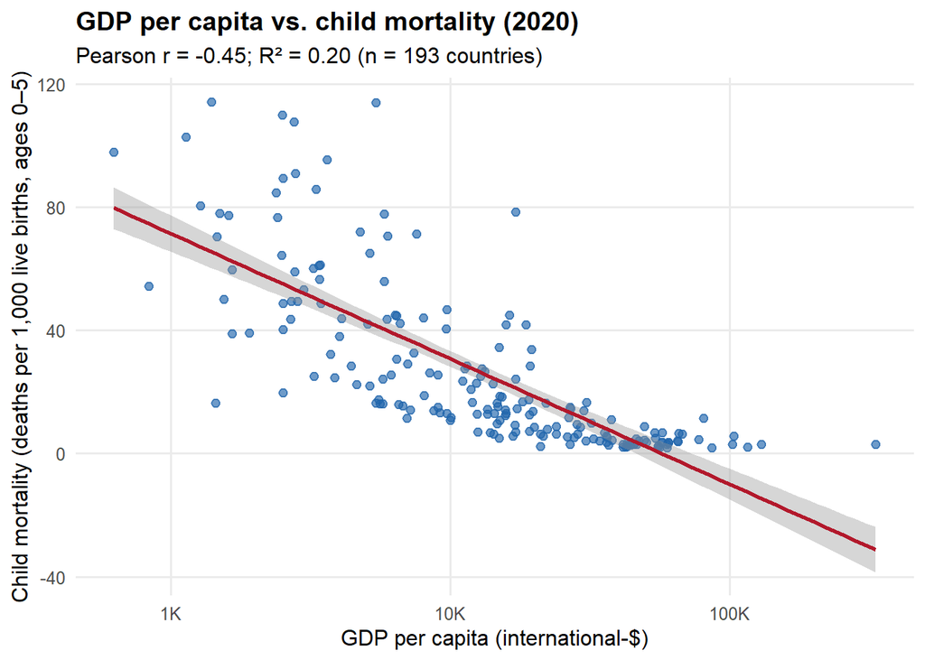

## Interpretation

The relationship is **nonlinear**: gains in GDP at low income levels coincide with especially large reductions in mortality, while among high-income countries both indicators level off (mortality approaches very low values). This pattern is visible on the log-scaled x-axis and matches the contrasting regional patterns in the two maps—regions with low GDP per capita in 2020 largely overlap those with elevated child mortality.

## Reflections

The use of AI tools simplifies and reduces the time needed to create this report. It was interesting to see how the AI tool handled the data and the code. It was able to generate the code quickly and accurately, and it was able to work around challenges encourntered during the analyis.